# As-a-Statistician-Group Sequential Design

Zehui Bai

2022-12-19 16:34:31

[interactive chart not shown]

在完成整体研究前，按预设的分析计划进行的数据分析叫做期中分析/期间分析（interim analysis）。在成组序贯检验（GTS）中,期中分析决定了是否提前终止试验。设计的期中分析越多，尽早停止的机会就越多，所需要的最大样本量 （maximum sample size）就越大，平均样本量（average sample size）越小。

- 盲态。由于期中分析可能包含了非盲态数据及结果，因此所有参与试验的人员中，除直接实施期中分析的人员之外，其他人员必须对这类分析的结果保持盲态。研究者仅仅会被告知是否继续试验或对试验方案进行修订。
- 严谨的“预”设计。任何设计不良的期中分析都可能使结果有误，所得结论缺乏可靠性，因此应避免这种分析。如进行了计划外的期中分析，在研究报告中应解释其必要性、破盲的必要性，提供可能导致的偏倚的严重程度以及对结果解释的影响。
  - 次数。比如一共进行3次。
  - 间距。可以由不同因素决定，可以分为：等距：在比如收集到25%、50%、75%的样本量时，非等距。
  - 确定整体误差水平（如0.05显著水平）
  - 确定提前停止的边际条件（Stopping Boundaries）
    - 有效边界（efficacy boundary）: 用alpha消耗函数（alpha spending function）调整总体样本量控制I类错误. 越过边界，则拒绝原假设（H0）
    - 无效边界（futility boundary）：使用beta消耗函数（beta-spending function）调整总体样本量，控制II类错误. 越过边界，则接受备择假设（H1）
- 是否采取调整设计（adaptive design）。是否根据期间分析结果，调整样本量，或者调整实验设计（从superiority trial调整为non-inferiority trial）

## Classical Designs without futility stopping

The design of many clinical trials includes some strategy for early stopping if an interim analysis reveals large differences between treatment groups, or shows obvious futility such that there is no chance that continuing to the end would show a clinically meaningful effect. In addition to saving time and resources, such a design feature can reduce study participants’ exposure to an inferior or useless treatment. However, when repeated significance testing on accumulating data is done, some adjustment of the usual hypothesis testing procedure must be made to maintain an overall significance level. The methods described by Pocock and O’Brien & Fleming, among others, are popular implementations of group sequential testing for clinical trials.

### Pocock Method

The Pocock boundary is a method for determining whether to stop a clinical trial prematurely. The typical clinical trial compares two groups of patients. One group are given a placebo or conventional treatment, while the other group of patients are given the treatment that is being tested. The investigators running the clinical trial will wish to stop the trial early for ethical reasons if the treatment group clearly shows evidence of benefit. In other words, “when early results proved so promising it was no longer fair to keep patients on the older drugs for comparison, without giving them the opportunity to change.”

The Pocock boundary is simple to use in that the p-value threshold is the same at each interim analysis. The disadvantages are that the number of interim analyses must be fixed at the start and it is not possible under this scheme to add analyses after the trial has started. Another disadvantage is that investigators and readers frequently do not understand how the p-values are reported: for example, if there are five interim analyses planned, but the trial is stopped after the third interim analysis because the p-value was 0.01, then the overall p-value for the trial is still reported as <0.05 and not as 0.01.

> Pocock边界易于使用，因为在每个临时分析中，P值阈值相同。缺点是必须在开始时固定临时分析的数量，并且在试验开始后不可能添加分析。另一个缺点是，调查人员和读者经常不了解如何报告P值：例如，如果计划进行五个临时分析，但是在第三次临时分析后停止了试验，因为P值为0.01，则该试验是在第三次中期分析，则应停止。该试验的总体p值仍报告为<0.05，不为0.01。

**With the Pocock design early rejections are more likely.**

### O’Brien & Fleming Method

Pocock (1977) first proposed that the crossing boundary be constant for all equally spaced analyses. O’Brien and Fleming $(1979)$ suggested that the crossing boundaries for the kth analysis, $z_{c}(k)$, be changed over the total number of analyses $\mathrm{K}$ such that

$$z_{c}(k)=z_{O B F} \sqrt{K / k}$$
The O’Brien-Fleming boundaries have been used more frequently because they preserve a nominal significance level at the final analysis that is close to that of a single test procedure.

With the O’Brien & Fleming design the early rejection bounds are large and early rejections are rather unlikely, at least under $\mathrm{H} _0$. With the O’Brien& Fleming design the last rejection bound is close to the un-adjusted bound $Z_{\alpha / 2}$. This is not the case for Pocock’s design. In practice, the O’Brien & Fleming design is generally preferred, since early rejection without overwhelming evidence may not be convincing.

> 使用O’Brien＆Fleming设计，早期的拒绝界限很大且早期拒绝不太可能

### Wang & Tsiatis Method

Wang & Tsiatis (1987) suggest the rejection boundaries

$$u_{k}=\mathrm{c}_{\mathrm{WT}}(K, \alpha, \beta, \Delta) k^{\Delta-0.5}$$

- For $\Delta=0$ we obtain the O’Brien & Fleming boundaries.
- For $\Delta=0.5$ we obtain Pocock’s boundaries
- For $0<\Delta<0.5$ we obtain a compromise between $\mathrm{P}$ and OBF.

### Rejection bounds and Local p-values

**Rejection bounds**

Rejection regions with rejection bounds $u_{k}, k=1, \ldots, K$.
$$\begin{array}{c}
\mathcal{R}_{k}^{*}=\left\{\left|Z_{k}^{*}\right| \geq u_{k}\right\}=\left(-\infty,-u_{k}\right) \cup\left(u_{k}, \infty\right) \\
\mathcal{A}_{k}^{*}=\emptyset, \mathcal{C}_{k}^{*}=\left(-u_{k}, u_{k}\right) \text { for } k<K, \text { and } \mathcal{A}_{K}^{*}=\left(-u_{K}, u_{K}\right)
\end{array}$$
Design of Pocock (1977): Constant rejection bounds, i.e.
$$u_{1}=\cdots=u_{K}=c_{\mathrm{P}} \text{with} c P=c P(K, \alpha)$$
such that
$$\mathbf{P}_{\mu_{0}}\left(\bigcup_{k=1}^{K}\left\{\left|Z_{k}^{*}\right| \geq c_{P}\right\}\right)=\alpha$$
Design of O’Brien & Fleming (1979): Decreasing rejection bounds with $u_{k}=c_{\mathrm{OBF}} / \sqrt{k}$ with $c \mathrm{OBF}=c \mathrm{OBF}(K, \alpha)$
$$\mathbf{P}_{\mu_{0}}\left(\bigcup_{k=1}^{K}\left\{\left|Z_{k}^{*}\right| \geq C_{\mathrm{OBF}} / \sqrt{k}\right\}\right)=\alpha$$

**Local p-values**

$$\begin{array}{c}
p_{k}^{*}:=2\left(1-\Phi\left(\left|Z_{k}^{*}\right|\right)\right), \quad k=1, \ldots, K \\
\text { Namely: } \quad\left|Z_{k}^{*}\right| \geq u_{k} \quad \Longleftrightarrow \quad p_{k}^{*} \leq \alpha_{k}:=2\left(1-\Phi\left(u_{k}\right)\right)
\end{array}$$

- Constant local levels in the Pocock design:
  $$\alpha_{1}=\cdots=\alpha_{K}=2\left(1-\Phi\left(C_{\mathrm{P}}\right)\right)$$
- Decreasing local levels of the O’Brien & Fleming design:
  $$\alpha_{k}=2\left(1-\Phi\left(c_{\mathrm{OBF}} / \sqrt{k}\right)\right), \quad k=1, \ldots, K$$

### Power and Sample size

As argued before, the maximum sample size $N_{K}$ required for power $1-\beta$ is a multiple of the **fixed size**
$$\begin{array}{l}
n_{f}=\left(z_{\alpha / 2}+z_{\beta}\right)^{2} / \delta_{1}^{2} \\
N_{K}=n_{f} \cdot I(K, \alpha, \beta)
\end{array}$$
The inflation factor $I(K, \alpha, \beta)$ depends on the type of design, e.g. whether Pocock or O’Brien & Fleming.

**Average Sample Size**

The required stage-wise sample size is
$$n=N_{K} / K=n_{f} \cdot I(K, \alpha, \beta) / K$$
Consequently, we get for the ASN
$$\frac{\operatorname{ASN}(\mu)}{n_{f}}=\frac{I(K, \alpha, \beta)}{K} \underbrace{\left(1+\sum_{k=2}^{K} \mathbf{P}_{\vartheta_{1}}\left(Z_{1}^{*} \in \mathcal{C}_{1}^{*}, \ldots, Z_{k-1}^{*} \in \mathcal{C}_{k-1}^{*}\right)\right)}_{\text {average number of stages }}$$

## Classical Designs with binding futility stopping

### Symmetric designs

Pampallona & Tsiatis (1994) suggest to use a GSD with a symmetric interim acceptance region:
$$\mathcal{A}_{k}^{*}=\left[-u_{k k}^{0}, u_{k}^{0}\right], \quad \mathcal{C}_{k}^{*}=\left(-u_{k}^{1},-u_{k}^{0}\right) \cup\left(u_{k}^{0}, u_{k}^{1}\right), \quad k=1, \ldots, K$$
for specific $0<u_{k}^{0}<u_{k}^{1}(k<K)$ and $0<u_{K}^{0}=u_{K}^{1}$ This means to accept $H_{0}$ at stage k if $|Z k| \leq u k^{0}$, and to reject $H_{0}$ at stage k if $\left|Z_{k}\right| \geq u_{k}^{1}$

The method can be implemented by using the acceptance bounds
$$u_{k}^{0}:=\max (\underbrace{\left[\sqrt{k / K}\left(c^{0}+c^{1}\right)-c^{0}\right] K^{\Delta-0.5}}_{\text {the original } u_{k}^{0}}, 0)$$

### One-Sided Designs

Without early acceptance we would now choose:
$$\begin{array}{c}
\mathcal{C}_{k}^{*}=\left(-\infty, u_{k}\right), \quad \mathcal{A}_{k}^{*}=\emptyset, \quad k=1, \ldots, K-1 \\
\mathcal{R}_{k}^{*}=\left[u_{k}, \infty\right), \quad k=1, \ldots, K, \quad \mathcal{A}_{K}^{*}=\left(-\infty, u_{K}\right)
\end{array}$$
Type I error rate control:
$$\mathbf{P}_{\mu_{0}}\left(\bigcup_{k=1}^{K}\left\{Z_{k}^{*} \geq u_{k}\right\}\right)=\alpha$$
One-sided GSD with early acceptance: DeMets & Ware $(1980,1982)$ suggest to use a constant futility boundary $u^{L}<u_{k}$ for all $k \leq K-1$, With this futility boundary the decision regions become
$$\begin{array}{c}
\mathcal{C}_{k}^{*}=\left(u^{L}, u_{k}\right), \quad \mathcal{A}_{k}^{*}=\left(-\infty, u^{L}\right), \quad k=1, \ldots, K-1 \\
\mathcal{R}_{k}^{*}=\left(u_{k}, \infty\right), \quad k=1, \ldots, K, \quad \mathcal{A}_{K}^{*}=\left(-\infty, u_{K}\right)
\end{array}$$

## Alpha Spending Function Approach

**GSD with unequally sized stages**

Assume that we have planned the GSD with equally spaced stages, but the stage-wise sample sizes $n_k$ are unequal. We can calculate all boundaries (e.g. Pocock or O’Brien & Fleming) also with unequal stages.

> 如果只是为了控制假阳性，可以将提前比较视为多次比较，使用多重检验方法进行校正。但是实验中数据相关性较强，多重校正会增大假阴性错误，并不合适。alpha消耗函数的思路是将假阳性错误按照某种方案分配给每次比较，每次比较消耗一定的假阳性配额，合计后刚好等于预设水平。 当某个临床研究分若干阶段进行整体决策时（如基于有效性或无效性所做的期中分析），每个阶段都要消耗一定的α，随着研究进展，研究所完成的比例（如1/3、1/2、60%等）与累积的I类错误率呈现某种函数关系. 每次消耗为
> $$\alpha_{1}^{*}=\alpha\left(t_{1}^{*}\right)-\alpha(0),$$
> $$\alpha_{2}^{*}=\alpha\left(t_{2}^{*}\right)-\alpha\left(t_{1}^{*}\right), \ldots,$$
> $$\alpha_{n}^{*}=\alpha(1)-\alpha\left(t_{n-1}^{*}\right)$$
> 根据定义可知$\alpha_{1}^{*}=\alpha\left(t_{1}^{*}\right), \sum \alpha^{*}=\alpha,$

It is usually difficult or even impossible to achieve the pre-planned sample sizes perfectly. One reason is that we need to fix a date for the DMC to meet. So solve this issue, Lan & DeMets suggest to fix the maximum sample size $\mathrm{N}$ and a “spending function at level” $\alpha^{*}(t), \quad t \in[0,1]$ that is strictly increasing with $\alpha(0)=0$ and $\alpha(1)=\alpha$

- In the 1 st interim analysis (IA) calculate $t_{1}=n_{1} / \mathrm{N}$ and $u_{1}, \mathrm{~s}$.th. $\mathbf{P}\left(\left|Z_{1}^{*}\right| \geq u_{1}\right)=\alpha^{*}\left(t_{1}\right)$
- In the 2nd IA we calculate $t_{2}=\left(n_{1}+n_{2}\right) / N$ and $u_{2}, \mathrm{~s}$.th. $\alpha_{1}^{*}\left(t_{1}\right)+\mathbf{P}\left(\left|Z_{1}^{*}\right|<u_{1},\left|Z_{2}^{*}\right| \geq u_{2}\right)=\alpha^{*}\left(t_{2}\right)$
- In the $k^{\text {th }}$ IA calculate $t k=(n 1+\cdots+n k) / N$ and $u_{k}$

$$\alpha^{*}\left(t_{k-1}\right)+\mathbf{P}\left(\left|Z_{1}^{*}\right|<u_{1}, \ldots,\left|Z_{k-1}^{*}\right|<u_{k-1},\left|Z_{k}^{*}\right| \geq u_{k}\right)=\alpha^{*}\left(t_{k}\right)$$
This means to use the level $\alpha^{*}\left(t_{k}\right)$ up to stage $k$

**Examples for spending functions**

- To mimic Pocock’s design (Lan & DeMets, 1983): $\alpha_{1}^{*}(t)=\alpha \log (1+(e-1) t), \quad t \in[0,1]$
- To mimic the O’Brien & Fleming design (Lan & DeMets, 1983): $\alpha_{2}^{*}(t)=\left\{\begin{array}{l}4\left\{1-\phi^{-1}\left[\Phi(1-\alpha / 4) / \sqrt{t_{k}}\right]\right\} \\ 4\left\{1-\phi^{-1}\left[\Phi(1-\alpha / 2) / \sqrt{t_{k}}\right]\right\} & \begin{array}{l}\text { one-sided } \\ \text { two-sided }\end{array}\end{array}\right.$
- Spending function family of Kim & DeMets (1987) $\alpha_{3}^{*}(\rho, t)=\alpha t^{\rho}, \quad t \in[0,1], \quad$ for some $\rho>0$

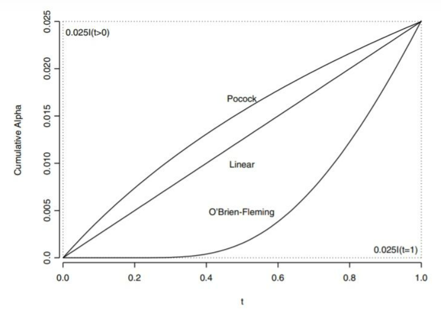

## R Implementation using rpact

[R Package for Adaptive Clinical Trials](https://www.rpact.org/vignettes)

[Shiny Apps](https://rpact.shinyapps.io/public/)

### Basic Functions

**Design Functions**

- getDesignGroupSequential()
- getDesignInverseNormal()
- getDesignFisher()
- getDesignCharacteristics()

**Sample Size Calculation Functions**

- getSampleSizeMeans()
- getSampleSizeRates()
- getSampleSizeSurvival()

**Power Calculation Functions**

- getPowerMeans()
- getPowerRates()
- getPowerSurvival()

**Simulation Functions**

- getSimulationMeans()
- getSimulationRates()
- getSimulationSurvival()
- getSimulationMultiArmMeans()
- getSimulationMultiArmRates()
- getSimulationMultiArmSurvival()

**Dataset and Analysis Results Functions**

- getDataset()
- getAnalysisResults()
- getStageResults()

### `getDesignGroupSequential` defining efficacy boundaries

```
typeOfDesign = c("OF", "P", "WT", "HP", "WToptimum",
                "asP", "asOF", "asKD", "asHSD", "asUser")
```

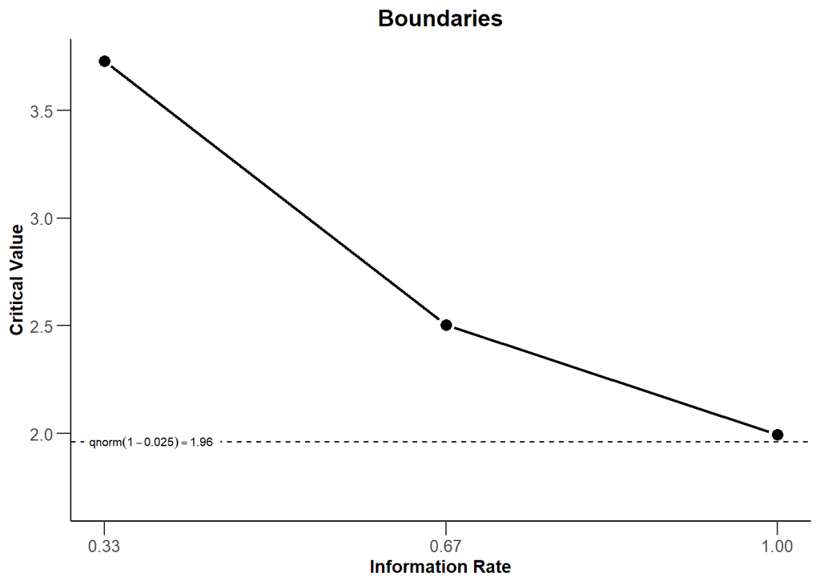

```r
library(rpact)
## Standard O’Brien & Fleming boundary
design <- getDesignGroupSequential(sided = 1, alpha = 0.025,
    informationRates = c(0.33, 0.67, 1), typeOfDesign = "OF")

## User-defined α-spending functions
## User-defined αα-spending functions (typeOfDesign = "asUser") can be obtained via the argument userAlphaSpending which must contain a numeric vector with elements 0<α1<…<αkMax=α0<α1<…<αkMax=α that define the values of the cumulative alpha-spending function at each interim analysis.
## Example: User-defined alpha-spending function which is very conservative at first interim (spend alpha = 0.001), conservative at second (spend an additional alpha = 0.01, i.e., total cumulative alpha spent is 0.011 up to second interim), and spends the remaining alpha at the final analysis (i.e., cumulative alpha = 0.025)
design <- getDesignGroupSequential(sided = 1, alpha = 0.025,
    informationRates = c(0.33, 0.67, 1),
    typeOfDesign = "asUser",
    userAlphaSpending = c(0.001, 0.01 + 0.001, 0.025))


## O’Brien & Fleming type α-spending
design <- getDesignGroupSequential(sided = 1, alpha = 0.025,
                                   informationRates = c(0.33, 0.67, 1),
                                   typeOfDesign = "asOF")


# plot the design with default type 1 (Boundary Plot)
plot(design)
```

```r
### plot.TrialDesign
### 1: creates a 'Boundaries' plot
### 3: creates a 'Stage Levels' plot
### 4: creates a 'Error Spending' plot
### 5: creates a 'Power and Early Stopping' plot
### 6: creates an 'Average Sample Size and Power / Early Stop' plot
### 7: creates an 'Power' plot
### 8: creates an 'Early Stopping' plot
### 9: creates an 'Average Sample Size' plot
### "all": creates all available plots and returns it as a grid plot or list

# summary() creates a nice presentation of the design:
summary(design)
```

```
## Sequential analysis with a maximum of 3 looks (group sequential design)
##
## O'Brien & Fleming type alpha spending design, one-sided overall
## significance level 2.5%, power 80%, undefined endpoint, inflation factor 1.013,
## ASN H1 0.8657, ASN H01 0.9827, ASN H0 1.0109.
##
## Stage                                   1       2       3
## Information rate                      33%     67%    100%
## Efficacy boundary (z-value scale)   3.731   2.504   1.994
## Stage Levels                      <0.0001  0.0061  0.0231
## Cumulative alpha spent            <0.0001  0.0062  0.0250
## Overall power                      0.0174  0.4227  0.8000
```

```r
# display the design characteristics
# Stopping probabilities and expected sample size reduction
getDesignCharacteristics(design)
```

```
## Group sequential design characteristics:
##   Number of subjects fixed                     : 7.8489
##   Shift                                        : 7.9510
##   Inflation factor                             : 1.0130
##   Informations                                 : 2.624, 5.327, 7.951
##   Power                                        : 0.01739, 0.42271, 0.80000
##   Rejection probabilities under H1             : 0.01739, 0.40532, 0.37729
##   Futility probabilities under H1              : 0, 0
##   Ratio expected vs fixed sample size under H1 : 0.8657
##   Ratio expected vs fixed sample size under a value between H0 and H1 : 0.9827
##   Ratio expected vs fixed sample size under H0 : 1.0109
```

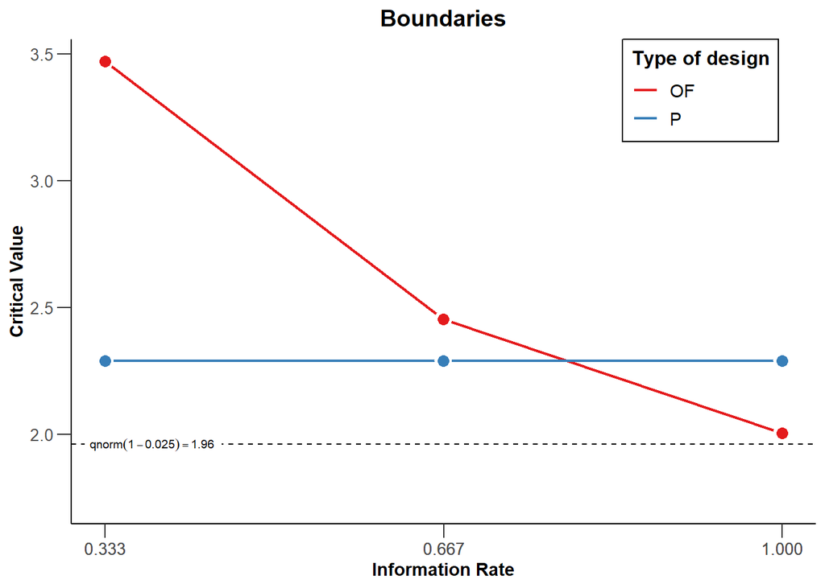

```r
### Comparison of multiple designs
# O'Brien & Fleming, 3 equally spaced stages
d1 <- getDesignGroupSequential(typeOfDesign = "OF", kMax = 3)
# Pocock
d2 <- getDesignGroupSequential(typeOfDesign = "P", kMax = 3)
designSet <- getDesignSet(designs = c(d1, d2), variedParameters = "typeOfDesign")
plot(designSet, type = 1)
```

### `futilityBounds` defining futility boundaries

- A futility bound of z=0 corresponds to an **estimated treatment effect of zero** or “null”, i.e., in this case futility stopping is recommended if the treatment effect estimate at the interim analysis is zero or “goes in the wrong direction”.
- utility bounds of z=−∞ (which are numerically equivalent to z=−6) correspond to no futility stopping at an interim.

```r
## Example: non-binding futility boundary at each interim in case
## estimated treatment effect is null or goes in "the wrong direction"
## See Futility boundary (z-value scale)
design <- getDesignGroupSequential(sided = 1, alpha = 0.025,
    informationRates = c(0.33, 0.67, 1), typeOfDesign = "asOF",
    futilityBounds = c(0,0), bindingFutility = FALSE)
summary(design)
```

```
## Sequential analysis with a maximum of 3 looks (group sequential design)
##
## O'Brien & Fleming type alpha spending design, non-binding futility,
## one-sided overall significance level 2.5%, power 80%, undefined endpoint,
## inflation factor 1.0605, ASN H1 0.8628, ASN H01 0.8689, ASN H0 0.6589.
##
## Stage                                   1       2       3
## Information rate                      33%     67%    100%
## Efficacy boundary (z-value scale)   3.731   2.504   1.994
## Stage Levels                      <0.0001  0.0061  0.0231
## Futility boundary (z-value scale)       0       0
## Cumulative alpha spent            <0.0001  0.0062  0.0250
## Overall power                      0.0191  0.4430  0.8000
## Futility probabilities under H1     0.049   0.003
```

## Sample Size

### Sample Sizes for Different Types of Endpoints without IA

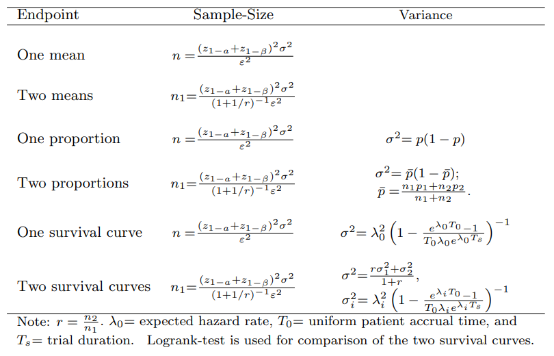

Figure: Sample Sizes for Different Types of Endpoints without IA

### Two groups continuous endpoint (without IA)

```r
### without interim analyses witrh equal sample size of 2 arms
### Assumption: Targeted mean difference is >0 under the alternative hypothesis
# Example of a standard trial:
# - targeted mean difference is 10 (alternative = 10)
# - standard deviation in both arms is assumed to be 24 (stDev = 24)
# - two-sided test (sided = 2), Type I error 0.05 (alpha = 0.05) and power 80%
# - (beta = 0.2)
sampleSizeResult <- getSampleSizeMeans(alternative = 10, stDev = 24, sided = 2,
         alpha = 0.05, beta = 0.2)
## sampleSizeResult
summary(sampleSizeResult)
```

```
## Sample size calculation for a continuous endpoint
##
## Fixed sample analysis, significance level 5% (two-sided).
## The sample size was calculated for a two-sample t-test, H0: mu(1) - mu(2) = 0,
## H1: effect = 10, standard deviation = 24, power 80%.
##
## Stage                               Fixed
## Efficacy boundary (z-value scale)   1.960
## Number of subjects                  182.8
## Two-sided local significance level 0.0500
## Lower efficacy boundary (t)        -7.006
## Upper efficacy boundary (t)         7.006
##
## Legend:
##   (t): treatment effect scale
```

```r
### Unequal randomization between the treatment groups
# - 2(intervention):1(control) randomization (allocationRatioPlanned = 2)
summary(getSampleSizeMeans(alternative = 10, stDev = 24,
    allocationRatioPlanned = 2, sided = 2, alpha = 0.05, beta = 0.2))
```

```
## Sample size calculation for a continuous endpoint
##
## Fixed sample analysis, significance level 5% (two-sided).
## The sample size was calculated for a two-sample t-test, H0: mu(1) - mu(2) = 0,
## H1: effect = 10, standard deviation = 24, planned allocation ratio = 2, power 80%.
##
## Stage                               Fixed
## Efficacy boundary (z-value scale)   1.960
## Number of subjects                  205.4
## Two-sided local significance level 0.0500
## Lower efficacy boundary (t)        -7.004
## Upper efficacy boundary (t)         7.004
##
## Legend:
##   (t): treatment effect scale
```

```r
### Calculate power for the 2:1 rendomized trial with total sample size 206
### (as above) assuming a larger difference of 12
powerResult <- getPowerMeans(alternative = 12, stDev = 24, sided = 2,
    allocationRatioPlanned = 2, maxNumberOfSubjects = 206, alpha = 0.05)
summary(powerResult)
```

```
## Power calculation for a continuous endpoint
##
## Fixed sample analysis, significance level 5% (two-sided).
## The results were calculated for a two-sample t-test, H0: mu(1) - mu(2) = 0,
## H1: effect = 12, standard deviation = 24, number of subjects = 206,
## planned allocation ratio = 2.
##
## Stage                               Fixed
## Efficacy boundary (z-value scale)   1.960
## Power                              0.9203
## Number of subjects                  206.0
## Two-sided local significance level 0.0500
## Lower efficacy boundary (t)        -6.994
## Upper efficacy boundary (t)         6.994
##
## Legend:
##   (t): treatment effect scale
```

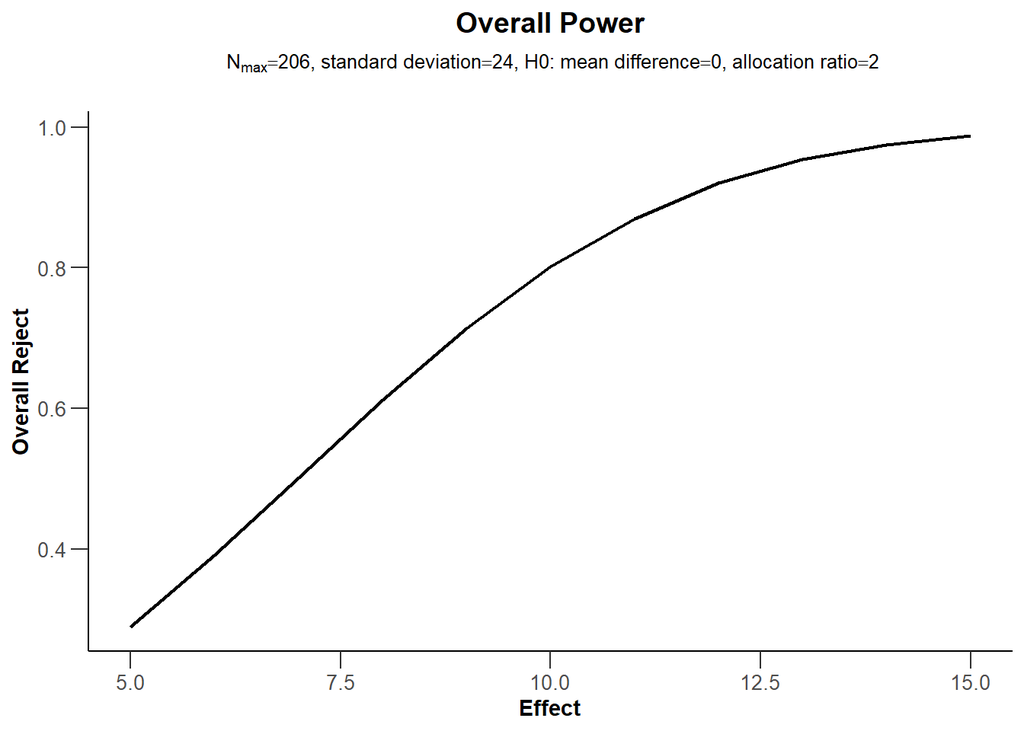

```r
### Two groups continuous endpoint (non-inferiority)
### Plpot the overall power
# Example: Calculate power for design with sample size 206 as above
# alternative values ranging from 5 to 15
powerResult <- getPowerMeans(alternative = 5:15, stDev = 24, sided = 2,
    allocationRatioPlanned = 2, maxNumberOfSubjects = 206, alpha = 0.05)
plot(powerResult,type = 7) # one of several possible plots
```

```r
# - One-sided alpha = 0.05, 1:1 randomization
# - H0: treatment difference <= -12 (i.e., = -12 for calculations, thetaH0 = -1)
#    vs. alternative H1: treatment difference = 0 (alternative = 0)
sampleSizeNoninf <- getSampleSizeMeans(thetaH0 = -12,alternative = 0,
    stDev = 14,alpha = 0.025,beta = 0.2,sided = 1)
sampleSizeNoninf
```

```
## Design plan parameters and output for means:
##
## Design parameters:
##   Critical values                              : 1.96
##   Significance level                           : 0.0250
##   Type II error rate                           : 0.2000
##   Test                                         : one-sided
##
## User defined parameters:
##   Theta H0                                     : -12
##   Alternatives                                 : 0
##   Standard deviation                           : 14
##
## Default parameters:
##   Mean ratio                                   : FALSE
##   Normal approximation                         : FALSE
##   Treatment groups                             : 2
##   Planned allocation ratio                     : 1
##
## Sample size and output:
##   Number of subjects fixed                     : 44.7
##   Number of subjects fixed (1)                 : 22.4
##   Number of subjects fixed (2)                 : 22.4
##   Critical values (treatment effect scale)     : -3.556
##
## Legend:
##   (i): values of treatment arm i
```

### Two groups binary endpoint (without IA)

```r
# - probability 25% in control (pi2 = 0.25) vs 40% (pi1 = 0.4) in intervention
# - one-sided test (sided = 1)
# - Type I error 0.025 (alpha = 0.025) and power 80% (beta = 0.2)
sampleSizeResult <- getSampleSizeRates(pi2 = 0.25, pi1 = 0.4,
    sided = 1, alpha = 0.025, beta = 0.2)
summary(sampleSizeResult)
```

```
## Sample size calculation for a binary endpoint
##
## Fixed sample analysis, significance level 2.5% (one-sided).
## The sample size was calculated for a two-sample test for rates
## (normal approximation),
## H0: pi(1) - pi(2) = 0, H1: treatment rate pi(1) = 0.4, control rate pi(2) = 0.25,
## power 80%.
##
## Stage                               Fixed
## Efficacy boundary (z-value scale)   1.960
## Number of subjects                  303.7
## One-sided local significance level 0.0250
## Efficacy boundary (t)               0.103
##
## Legend:
##   (t): treatment effect scale
```

```r
# Example: Calculate power for a simple trial with total sample size 304
# as in the example above in case of pi2 = 0.25 (control) and
# pi1 = 0.37 (intervention)
powerResult <- getPowerRates(pi2 = 0.25, pi1 = 0.37, allocationRatioPlanned = 2,
    maxNumberOfSubjects = 304, sided = 1,alpha = 0.025)
summary(powerResult)
```

```
## Power calculation for a binary endpoint
##
## Fixed sample analysis, significance level 2.5% (one-sided).
## The results were calculated for a two-sample test for rates (normal approximation),
## H0: pi(1) - pi(2) = 0, power directed towards larger values,
## H1: treatment rate pi(1) = 0.37, control rate pi(2) = 0.25,
## number of subjects = 304, planned allocation ratio = 2.
##
## Stage                               Fixed
## Efficacy boundary (z-value scale)   1.960
## Power                              0.5571
## Number of subjects                  304.0
## One-sided local significance level 0.0250
## Efficacy boundary (t)               0.112
##
## Legend:
##   (t): treatment effect scale
```

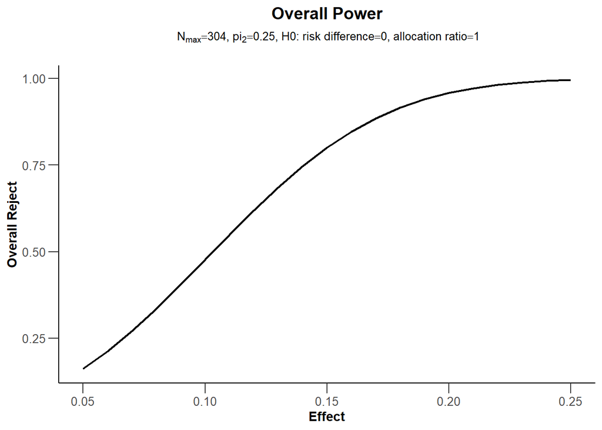

```r
# Example: Calculate power for simple design (with sample size 304 as above)
# for probabilities in intervention ranging from 0.3 to 0.5
powerResult <- getPowerRates(pi2 = 0.25,pi1 = seq(0.3,0.5,by = 0.01),
    maxNumberOfSubjects = 304,sided = 1,alpha = 0.025)
# one of several possible plots, this one plotting true effect size vs power
plot(powerResult,type = 7)
```

```r
### for a single arm trial without interim analyses
# Example: Sample size for a single arm trial which tests
# H0: pi = 0.1 vs. H1: pi = 0.25
# (use conservative exact binomial calculation)
samplesSizeResults <- getSampleSizeRates(groups = 1, thetaH0 = 0.1, pi1 = 0.25,
    normalApproximation = FALSE, sided = 1, alpha = 0.025, beta = 0.2)
summary(samplesSizeResults)
```

```
## Sample size calculation for a binary endpoint
##
## Fixed sample analysis, significance level 2.5% (one-sided).
## The sample size was calculated for a one-sample test for rates (exact test),
## H0: pi = 0.1, H1: treatment rate pi = 0.25, power 80%.
##
## Stage                               Fixed
## Efficacy boundary (z-value scale)   1.960
## Number of subjects                   53.0
## One-sided local significance level 0.0250
## Efficacy boundary (t)               0.181
##
## Legend:
##   (t): treatment effect scale
```

### Group-sequential designs for conti and binary

Sample size calculation for a group-sequential trials is performed in two steps:

1. Define the (abstract) group-sequential design using the function getDesignGroupSequential(). For details regarding this step, see the R markdown file “Defining group-sequential boundaries with rpact”.
2. Calculate sample size for the continuous endpoint by feeding the abstract design into the function getSampleSizeMeans().

```r
# Example: Group-sequential design with  O'Brien & Fleming type alpha-spending
# and one interim at 60% information
design <- getDesignGroupSequential(sided = 1, alpha = 0.025, beta = 0.2,
    informationRates = c(0.6,1), typeOfDesign = "asOF")

# Trial assumes an effect size of 10 as above, a stDev = 24, and an allocation
# ratio of 2
sampleSizeResultGS <- getSampleSizeMeans(
    design, alternative = 10, stDev = 24, allocationRatioPlanned = 2)
# Standard rpact output (sample size object only, not design object)
summary(sampleSizeResultGS)
```

```
## Sample size calculation for a continuous endpoint
##
## Sequential analysis with a maximum of 2 looks (group sequential design), overall
## significance level 2.5% (one-sided).
## The sample size was calculated for a two-sample t-test, H0: mu(1) - mu(2) = 0,
## H1: effect = 10, standard deviation = 24, planned allocation ratio = 2, power 80%.
##
## Stage                                         1      2
## Information rate                            60%   100%
## Efficacy boundary (z-value scale)         2.669  1.981
## Overall power                            0.3123 0.8000
## Expected number of subjects               181.3
## Number of subjects                        124.3  207.1
## Cumulative alpha spent                   0.0038 0.0250
## One-sided local significance level       0.0038 0.0238
## Efficacy boundary (t)                    12.393  7.050
## Exit probability for efficacy (under H0) 0.0038
## Exit probability for efficacy (under H1) 0.3123
##
## Legend:
##   (t): treatment effect scale
```

```r
# Example: Group-sequential design with  O'Brien & Fleming type alpha-spending and
# one interim at 60% information
design <- getDesignGroupSequential(sided = 1, alpha = 0.025, beta = 0.2,
    informationRates = c(0.6, 1), typeOfDesign = "asOF")

# Sample size calculation assuming event probabilities are 25% in control
# (pi2 = 0.25) vs 40% (pi1 = 0.4) in intervention
sampleSizeResultGS <- getSampleSizeRates(design,pi2 = 0.25,pi1 = 0.4)
# Standard rpact output (sample size object only, not design object)
sampleSizeResultGS
```

```
## Design plan parameters and output for rates:
##
## Design parameters:
##   Information rates                            : 0.600, 1.000
##   Critical values                              : 2.669, 1.981
##   Futility bounds (non-binding)                : -Inf
##   Cumulative alpha spending                    : 0.003808, 0.025000
##   Local one-sided significance levels          : 0.003808, 0.023798
##   Significance level                           : 0.0250
##   Type II error rate                           : 0.2000
##   Test                                         : one-sided
##
## User defined parameters:
##   Assumed treatment rate                       : 0.400
##   Assumed control rate                         : 0.250
##
## Default parameters:
##   Risk ratio                                   : FALSE
##   Theta H0                                     : 0
##   Normal approximation                         : TRUE
##   Treatment groups                             : 2
##   Planned allocation ratio                     : 1
##
## Sample size and output:
##   Direction upper                              : TRUE
##   Reject per stage [1]                         : 0.3123
##   Reject per stage [2]                         : 0.4877
##   Early stop                                   : 0.3123
##   Maximum number of subjects                   : 306.3
##   Maximum number of subjects (1)               : 153.2
##   Maximum number of subjects (2)               : 153.2
##   Number of subjects [1]                       : 183.8
##   Number of subjects [2]                       : 306.3
##   Expected number of subjects under H0         : 305.9
##   Expected number of subjects under H0/H1      : 299.3
##   Expected number of subjects under H1         : 268.1
##   Critical values (treatment effect scale) [1] : 0.187
##   Critical values (treatment effect scale) [2] : 0.104
##
## Legend:
##   (i): values of treatment arm i
##   [k]: values at stage k
```

### Survival endpoint

The relevant rpact functions for survival are:

- `getPowerSurvival()`: This function is the analogue to getSampleSizeSurvival() for the calculation of power rather than the sample size.
- `getEventProbabilities()`: Calculates the probability of an event depending on the time and type of accrual, follow-up time, and survival distribution. This is useful for aligning interim analyses for different time-to-event endpoints.
- `getSimulationSurvival()`: This function simulates group-sequential trials. For example, it allows to assess the power of trials with delayed treatment effects or to assess the data-dependent variability of the timing of interim analyses even if the protocol assumptions are perfectly fulfilled. It also allows to simulate hypothetical datasets for trials stopped early.

#### Specifying survival distributions

**Exponential survival distributions**

- Event probability at a specific time point known `eventTime = 24, pi2 = 0.3, pi1 = 0.2`
- Exponential parameter $\lambda$ known
- Median survival known $\lambda = \log(2)/\text{median}$

**Weibull survival distributions**

Additional scale parameter kappa needs to be provided which is 1 for the exponential distribution.

#### Without interim analyses

**Exponential survival, flexible accrual intensity, no interim analyses**

- Exponential PFS with a median PFS of 60 months in control (lambda2 = log(2)/60) and a target hazard ratio of 0.74 (hazardRatio = 0.74).
- Log-rank test at the two-sided 5%-significance level (sided = 2, alpha = 0.05), power 80% (beta = 0.2).
- Annual drop-out of 2.5% in both arms (dropoutRate1 = 0.025, dropoutRate2 = 0.025, dropoutTime = 12).
- Recruitment is 42 patients/month from month 6 onwards after linear ramp up. (accrualTime = c(0,1,2,3,4,5,6), accrualIntensity = c(6,12,18,24,30,36,42))
- Randomization ratio 1:1 (allocationRatioPlanned = 1). This is the default and is thus not explicitly set in the function call below.
- Two sample size choices will be initially explored:
  - A fixed total sample size of 1200 (maxNumberOfSubjects = 1200).
  - Alternatively, the total sample size will be implicitly determined by specifying that every subject must have a minimal follow-up duration of at 12 months at the time of the analysis (followUpTime = 12).

```r
sampleSize1 <- getSampleSizeSurvival(sided = 2,alpha = 0.05,beta = 0.2,
    lambda2 = log(2)/60,hazardRatio = 0.74,
    dropoutRate1 = 0.025, dropoutRate2 = 0.025, dropoutTime = 12,
    accrualTime = c(0,1,2,3,4,5,6),
    accrualIntensity = c(6,12,18,24,30,36,42),
    maxNumberOfSubjects = 1200)
summary(sampleSize1)
```

```
## Sample size calculation for a survival endpoint
##
## Fixed sample analysis, significance level 5% (two-sided).
## The sample size was calculated for a two-sample logrank test,
## H0: hazard ratio = 1, H1: hazard ratio = 0.74, control lambda(2) = 0.012,
## number of subjects = 1200, accrual time = c(1, 2, 3, 4, 5, 6, 31.571),
## accrual intensity = c(6, 12, 18, 24, 30, 36, 42), dropout rate(1) = 0.025,
## dropout rate(2) = 0.025, dropout time = 12, power 80%.
##
## Stage                               Fixed
## Efficacy boundary (z-value scale)   1.960
## Number of subjects                 1200.0
## Number of events                    346.3
## Analysis time                        53.1
## Expected study duration              53.1
## Two-sided local significance level 0.0500
## Lower efficacy boundary (t)         0.810
## Upper efficacy boundary (t)         1.234
##
## Legend:
##   (t): treatment effect scale
```